# ADPS 2023Z — Laboratorium 2 (rozwiązania)

Bartolini Bartłomiej herbu Zielona Pietruszka

# Zadanie 1 (1 pkt)

## Treść zadania

Rozkład Poissona jest często używany do modelowania ruchu ulicznego (o małym natężeniu). Plik skrety.txt zawiera liczby pojazdów skręcających na pewnym skrzyżowaniu w prawo w przeciągu trzystu 3-minutowych przedziałów czasu (dane zostały zebrane o różnych porach dnia).

- Wczytaj dane za pomocą komendy scan(‘skrety.txt’).
- Dopasuj do danych rozkład Poissona, tj. wyestymuj parametr $\lambda$ rozkładu Poissona.
- Metodą bootstrapu nieparametrycznego oszacuj odchylenie standardowe estymatora parametru $\lambda$.
- Sprawdź i opisz zgodność rozkładu o wyestymowanym parametrze $\lambda$ z zarejestrowanymi danymi porównując graficznie empiryczną i teoretyczną funkcję prawdopodobieństwa. Użyj funkcji table() i dpois() analogicznie jak w przykładzie 4 laboratorium 1.

## Rozwiązanie

Wczytanie danych:

```r
traffic_data =  scan('skrety.txt')
```

```
Read 300 items
```

Estymacja parametru $\lambda$:

```r
est_lambda = mean(traffic_data)
```

Wyznaczenie odchylenia standardowego estymatora metodą bootstrapu nieparametrycznego:

```r
K = 1000
bootstrap_lambda = replicate(K, {
  boot_dane = sample(traffic_data, replace = T)
  return(mean(boot_dane))
})
sd_est_lambda = sd(bootstrap_lambda)
```

Odchylenie standardowe estymatora parametru $\lambda$ wynosi 0.1348.

Wykresy empirycznej i teoretycznej funkcji prawdopodobieństwa:

```r
F_emp = table(traffic_data)
F_teor = dpois(as.numeric(names(F_emp)), lambda = est_lambda)
plot(0:12, F_teor,type = "p", ylim = c(0, 0.25), pch = 4, col = "green4",
     las = 1, lwd = 2, main = "Funkcje prawdopodobieństwa", xaxt = "n",
     xlab = expression(italic("k")), ylab = expression("P" ~ italic("(x=k)")))
points(F_emp / length(traffic_data), type = "p", pch = 3, col = "red3")
```

```r
legend("topright", legend = c("teoretyczna", "empiryczna"), col = c("green4", "red3"),
       pch = c(4, 3), bg = "white")
axis(1, at = 0:12)
```

[figure not shown]

```r
abline(h = seq(0, 0.25, by = 0.05), v = 0:12, lty = 2, col = "grey")
```

```r
NA
NA
```

# Zadanie 2 (1 pkt)

## Treść zadania

- Dla wybranej jednej spółki notowanej na GPW oblicz wartości procentowych zmian najwyższych cen w dniu (high) w ciągu ostatniego roku i wykreśl ich histogram.
- Wyestymuj wartość średnią oraz wariancję procentowych zmian najwyższych cen w dniu dla wybranej spółki.
- Na podstawie histogramu i wykresu funkcji gęstości prawdopodobieństwa wyznaczonej dla wyestymowanych parametrów (wartość średnia i wariancja) zweryfikuj zgrubnie, czy możemy przyjąć, że procentowe zmiany najwyższych cen w dniu mają rozkład normalny.
- Zakładając, że zmiany najwyższych cen w dniu mają rozkład normalny wyznacz 90%, 95% i 99% przedziały ufności dla wartości średniej i wariancji procentowych zmian najwyższych cen w dniu dla wybranej spółki. Przeanalizuj wyniki uzyskane dla różnych przedziałów ufności.

## Rozwiązanie

Przygotowanie danych

```r
unzip('mstall.zip', files = 'CREOTECH.mst')
df_CREOTECH = read.csv('CREOTECH.mst')

names(df_CREOTECH) = c('ticker', 'date', 'open', 'high', 'low', 'close','vol')
df_CREOTECH$date = as.Date.character(df_CREOTECH$date, format ='%Y%m%d')
```

Ograniczenie do danych z dwunastu miesięcy od ostatniej dostępnej daty:

```r
library(lubridate)
latest_date_CREOTECH = max(df_CREOTECH$date)
df_CREOTECH = df_CREOTECH[which(df_CREOTECH$date >= latest_date_CREOTECH %m-% months(12)),]
```

Dodanie kolumny z procentowymi zmianami najwyższego kursu dziennego:

```r
df_CREOTECH$high_diff = with(df_CREOTECH, c(NA, 100*diff(high)/high[-length(high)]))
```

Utworzenie histogramu (przedziały półprocentowe):

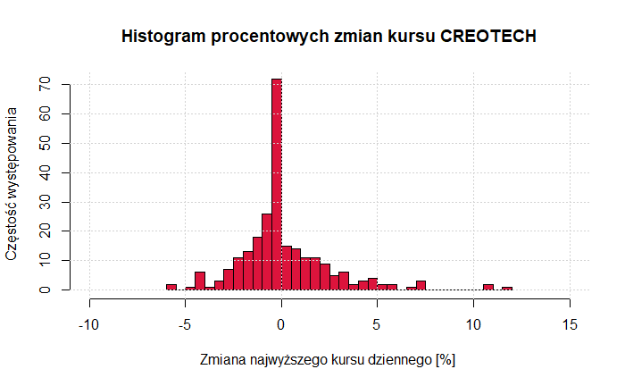

```r
hist(df_CREOTECH$high_diff,
breaks = 40, prob = F,
xlab = 'Zmiana najwyższego kursu dziennego [%] ',
ylab = 'Częstość występowania',
xlim = c(-10, 15),
main = paste('Histogram procentowych zmian kursu', 'CREOTECH'), col = '#DC143C')
grid()
```

# Zadanie 3 (1,5 pkt.)

## Treść zadania

Rzucona pinezka upada ostrzem do dołu lub do góry. Doświadczenie to można opisać rozkładem Bernoulliego z parametrem $p$ będącym prawdopodobieństwem tego, że pinezka upadnie ostrzem do góry.

Rozkład parametru $p$ można opisać rozkładem beta o parametrach $\alpha$ i $\beta$. Wartość średnia i wariancja w rozkładzie beta zależą od parametrów rozkładu w następujący sposób:
$$\mathbb{E}X = \frac{\alpha}{\alpha
+ \beta}, \qquad \mathbb{V}X = \frac{\alpha\beta}{(\alpha +
\beta)^2(\alpha + \beta + 1)}, \qquad dominanta = \frac{\alpha -
1}{\alpha + \beta - 2}.$$

- Na podstawie przypuszczanej (a priori) wartości oczekiwanej parametru $p$ zaproponuj wartości parametrów $\alpha$ i $\beta$ rozkładu a priori parametru $p$. Narysuj rozkład a priori parametru $p$ (wykorzystaj funkcję dbeta()).
- Rzuć pinezką 20 razy i zanotuj wyniki kolejnych rzutów (1 - pinezka upada ostrzem do góry, 0 - pinezka upada ostrzem do dołu). Wyznacz i narysuj rozkład a posteriori parametru $p$ oraz oblicz wartość bayesowskiego estymatora $\hat{p}$. W rozważanym przypadku rozkład aposteriori parametru $p$ jest również rozkładem beta o parametrach:
  $$\alpha_{\textrm{post}} =
  \alpha_{\textrm{prior}} + \sum_{i=1}^n x_i, \qquad \beta_{\textrm{post}}
  = \beta_{\textrm{prior}} + n - \sum_{i=1}^n x_i,\qquad
  x_i\in\{0,1\}.$$
- Rzuć pinezką jeszcze 20 razy i zanotuj wyniki. Wyznacz i narysuj rozkład a posteriori oparty na wszystkich 40 rzutach oraz oblicz wartość bayesowskiego estymatora $\hat{p}$ w tym przypadku. Porównaj wyniki z wynikami uzyskanymi po pierwszych 20 rzutach.
- Korzystając ze wzoru na wariancję rozkładu Beta wyznacz i porównaj wariancje rozkładów a priori, a posteriori po 20 rzutach i a posteriori po 40 rzutach.

## Rozwiązanie

# Zadanie 4 (1,5 pkt.)

## Treść zadania

Plik fotony.txt zawiera odstępy między chwilami rejestracji kolejnych fotonów promieniowania gamma wykonywanymi za pomocą teleskopu kosmicznego Comptona (CGRO) w roku 1991.

- Wczytaj dane za pomocą komendy scan(‘fotony.txt’)
- Metodą momentów oraz metodą największej wiarygodności wyznacz estymaty parametrów rozkładu gamma odpowiadające zarejestrowanym danym. Porównaj wyniki uzyskane dla obu metod.
- Narysuj na jednym wykresie histogram odstępów oraz funkcje gęstości rozkładu gamma o parametrach wyestymowanych za pomocą obu metod.
- Metodą bootstrapu parametrycznego wyznacz dla obu metod (momentów oraz największej wiarygodności) odchylenia standardowe estymatorów parametrów rozkładu gamma ($\alpha$ i $\beta$) oraz ich przedziały ufności na poziomie ufności 95%. Porównaj wyniki uzyskane dla obu metod.